# Assignment 4 ST466

Alok Kumar Singh 19250990

02:39:11 PM 01 May, 2020

## Question:-

A MSc student is analyzing the quality of a recent demographic survey in Ireland. She wants to assess the chance of incorrect reporting of the number of children over 5. She proceeds as follows: from all births that were reported to have occurred 5 to 10 years before the survey, she selects a random sample of 100 births. She then does a follow up survey to verify if these births if they were correctly reported. She finds that 10 births were reported incorrectly.

Let theta be the proportion of incorrectly reported births among all reported births 5 to 10 years before the survey. Assume Y |theta ∼ Bin(N, theta) and use a Bayesian approach to obtain the posterior distribution for theta based on the following:

1. Suppose that the MSc student had only considered values greater than 0.5 to be plausible outcomes for theta. Use a discrete prior distribution on theta to reflect the MSc students prior assumption. Obtain and plot the posterior distribution. Report the posterior mean and interpret your findings.

```r
library(tidyverse)
n = 100
y = 10

theta <- seq(0.5,1,by = 0.1)
likelihood <- dbinom(x = 10,size = 100,prob = theta)

## Value of discrete Prior is:-
prior <- 1/length(theta)
prior
```

```
## [1] 0.1666667
```

```r
## value of marginal likelihood
mlik <- 1/length(theta)*(sum(dbinom(10, 100, prob = theta)))
mlik
```

```
## [1] 2.275904e-18
```

```r
## Value of posterior distribtion is:-
posterior <- likelihood*prior/mlik
posterior
```

```
## [1] 1.000000e+00 1.174658e-08 3.125308e-19 1.684997e-34 4.420024e-61
## [6] 0.000000e+00
```

```r
## Posterior mean is:-
posterior_mean <- sum(posterior*theta)
posterior_mean
```

```
## [1] 0.5
```

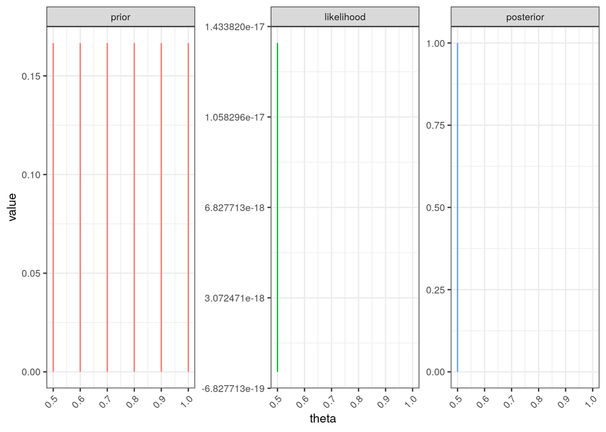

```r
## Plot of posterior distribution
binom_ex <- tibble(theta, prior, likelihood, posterior)

binom_ex <- binom_ex %>% pivot_longer(cols = prior:posterior,
                                      names_to = "type",
                                      values_to = "value") %>%
  mutate(type = factor(type, levels =c("prior","likelihood","posterior")))

p1 <- ggplot(binom_ex, aes(x = theta, y = value)) +
  geom_segment(aes(x = theta, y = value, xend=theta,yend=0, colour = type)) +
  facet_wrap(~type, scales = "free") +
  theme_bw()+
  theme(legend.position = "none",
        text = element_text(size=10),
        axis.text.x = element_text(angle=45, hjust=1)) +
  xlab("theta")
p1
```

Interpretation:-

posterior mean is:- 0.5

prior assumption in the given data is not appropriate as posterior distribution seems to be driven by prior.

2. Instead of assuming a discrete prior, assume an appropriate Uniform prior distribution on theta. Provide a point estimate and a 95% credible interval for the proportion of incorrectly reported births. How does this compare to the results from (a)?

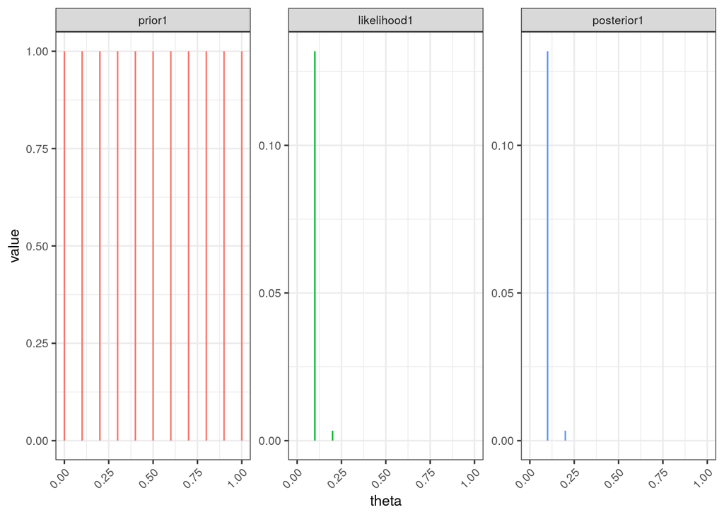

```r
theta1 <- seq(0,1,by = 0.1)
prior1 <- dunif(theta1, 0,1)
likelihood1 <- dbinom(x = 10,size = 100,prob = theta1)

posterior1 <- likelihood1*prior1

binom_ex1 <- tibble(theta1, prior1, likelihood1,posterior1)

binom_ex1 <- binom_ex1 %>% pivot_longer(cols = prior1:posterior1,
                                      names_to = "type",
                                      values_to = "value") %>%
  mutate(type = factor(type, levels =c("prior1","likelihood1","posterior1")))

p2 <- ggplot(binom_ex1, aes(x = theta1, y = value)) +
  geom_segment(aes(x = theta1, y = value, xend=theta1,yend=0, colour = type)) +
  facet_wrap(~type, scales = "free") +
  theme_bw()+
  theme(legend.position = "none",
        text = element_text(size=10),
        axis.text.x = element_text(angle=45, hjust=1)) +
  xlab("theta")
p2
```

```r
?theme
## posterior mean
posterior_mean1 <- (y+1)/(n+2)
posterior_mean1
```

```
## [1] 0.1078431
```

```r
## 95% credible interval for the proportion of incorrectly reported births
qbeta(c(0.025,0.975), y+1,n-y+1)
```

```
## [1] 0.05563722 0.17455283
```

Interpretation:-

posterior mean when we are using uniform disribution is :- 0.107

so we can say that uniform prior distribution in b is more appropriate then the discrete prior distribution in a.